# Differential Methylation Analysis on CpG (1KO_DKO)

Authors

Olivier Kirsh[^1]

Elouan Bethuel[^2]

28 May, 2024

```r
# load the config file
yaml.file <- yaml.load_file('config_ongoing_run.yaml')
meta <- read.table(yaml.file$METAFILE, sep='\t', header=T)

#Argument Parser
RDATA_DMT <- params$param1
CONDI <- params$param2
RDATA_PREP_FIGS <- params$param3
PLOT_RDATA <- params$param4
OUTPUT_PATH <- params$param5

control.cond <- unlist(strsplit(CONDI, "_"))[1]
treat.cond <- unlist(strsplit(CONDI, "_"))[2]
mark <- unlist(strsplit(CONDI, "_"))[3]

LEVEL <- yaml.file$LEVEL
CUSTOM_ANNOT <- yaml.file$CUSTOM_ANNOT

# colors - pinkish
#full.color = "#de0000"
#high.color = "#ff8092"
#mid.color  = "#f5e0e8"
#low.color = "#996d9a"
#unmeth.color = "#0a1661"
#hyper.color = "#de0000"
#hypo.color = "#0a1661"
#not.color = "#f5e0e8"

# moins rose
full.color = "#de0000"
high.color = "#e17e65"
mid.color  = "#c6c6c6"
low.color = "#7c6fac"
unmeth.color = "#0f208f"
hyper.color = "#de0000"
hypo.color = "#0f208f"
not.color = "#c6c6c6"

# couleurs Elouan
#full.color = "#342A1F",
#high.color = "#C59434",
#mid.color  = "#6F7498",
#low.color = "#A3B7F9",
#unmeth.color = "#F4D4D4"

titre <- paste0("Differential Methylation Analysis on ", LEVEL, " (", CONDI, ")")
```

MKit_differential.Rmd : Developped & Maintained by Olivier Kirsh and Elouan Bethuel.  
Perform a differential methylation analysis between pair of conditions.  
Launch as Rscript on HPC cluster with the workflow : WGBSflow.  
Requires 2 RData environments produced by the following R scripts :  
- MKit_diff_bed.R which performs MethylKit DM CpG (DMC) or Tiles (DMT) analysis,  
- MKit_diff_fig.R which builds all dataframes (wide and long format) needed to build the figures.

# 1 Load packages

```r
#load packages
library(ggplot2)
library(dbplyr)
library(magrittr)
library(methylKit)
library(yaml)
library(stringr)
```

# 2 Load RDATA

```r
load(RDATA_DMT)
load(RDATA_PREP_FIGS)
```

# 3 Configuration file parameters review

```r
# extract the information from the yaml file
MINCOV <- yaml.file$MINCOV
MINQUALI <- yaml.file$MINQUALI
UNITE <- yaml.file$UNITE
TILESIZE <- yaml.file$TILESIZE
STEPSIZE <- yaml.file$STEPSIZE
SIGNIDIF <- yaml.file$SIGNIDIF
QVALUE <- yaml.file$QVALUE
DESTRAND <- yaml.file$DESTRAND
merge_annot <- yaml.file$MERGE_WITH_BASICS_ANNOT
```

- Analysis on CpG or Tiles - LEVEL : CpG
- Merge reads from both strands? DESTRAND : TRUE
- Minimum coverage - MINCOV : 5
- Discards the bases that have more than COV.PERCth percentile of coverage - COV.PERC : 99.9
- Type of unification (all or at least one per group) - UNITE : all
- Threshold for significant differential methylation in % : 20
- Qvalue for significant differential methylation: 0.05

# 4 Overview of all methylkit objects used to perform figures

## 4.1 dm

```r
head(dm_condi, n = 20)
```

```
## [[1]]
## methylRaw object with 77141 rows
## --------------
##     chr   start     end strand coverage numCs numTs
## 1 chr19 3051793 3051793      -        1     0     1
## 2 chr19 3051820 3051820      -        1     0     1
## 3 chr19 3051822 3051822      -        1     0     1
## 4 chr19 3051861 3051861      -        1     1     0
## 5 chr19 3051903 3051903      -        2     0     2
## 6 chr19 3051908 3051908      -        2     0     2
## --------------
## sample.id: 1KO_1
## assembly: mm39
## context: CpG
## resolution: base
##
##
## [[2]]
## methylRaw object with 83572 rows
## --------------
##     chr   start     end strand coverage numCs numTs
## 1 chr19 3050119 3050119      +        1     0     1
## 2 chr19 3050120 3050120      -        1     0     1
## 3 chr19 3050317 3050317      -        1     0     1
## 4 chr19 3050813 3050813      -        1     0     1
## 5 chr19 3050818 3050818      -        1     0     1
## 6 chr19 3050955 3050955      +        1     1     0
## --------------
## sample.id: DKO_1
## assembly: mm39
## context: CpG
## resolution: base
##
##
## [[3]]
## methylRaw object with 81732 rows
## --------------
##     chr   start     end strand coverage numCs numTs
## 1 chr19 3050603 3050603      +        1     0     1
## 2 chr19 3051012 3051012      +        1     0     1
```

[output cut: 11 more lines]

```
## [[4]]
## methylRaw object with 67543 rows
## --------------
##     chr   start     end strand coverage numCs numTs
## 1 chr19 3051154 3051154      +        2     0     2
## 2 chr19 3051895 3051895      -        1     0     1
## 3 chr19 3051903 3051903      -        2     0     2
## 4 chr19 3051908 3051908      -        2     1     1
## 5 chr19 3051914 3051914      -        2     1     1
## 6 chr19 3052077 3052077      +        1     1     0
## --------------
## sample.id: DKO_2
## assembly: mm39
## context: CpG
## resolution: base
```

## 4.2 f.dm

```r
head(f.dm_condi, n = 20)
```

```
## [[1]]
## methylRaw object with 38271 rows
## --------------
##      chr   start     end strand coverage numCs numTs
## 38 chr19 3078799 3078799      +        5     3     2
## 44 chr19 3078955 3078955      +        6     1     5
## 53 chr19 3079664 3079664      -        5     0     5
## 65 chr19 3080405 3080405      +        5     0     5
## 67 chr19 3080609 3080609      +       11     1    10
## 71 chr19 3081126 3081126      +        7     1     6
## --------------
## sample.id: 1KO_1
## assembly: mm39
## context: CpG
## resolution: base
##
##
## [[2]]
## methylRaw object with 32249 rows
## --------------
##      chr   start     end strand coverage numCs numTs
## 40 chr19 3078603 3078603      +        9     1     8
## 41 chr19 3078604 3078604      -        5     1     4
## 42 chr19 3078649 3078649      +        7     1     6
## 47 chr19 3078832 3078832      -        6     0     6
## 50 chr19 3078956 3078956      -        7     2     5
## 53 chr19 3079445 3079445      -        6     2     4
## --------------
## sample.id: DKO_1
## assembly: mm39
## context: CpG
## resolution: base
##
##
## [[3]]
## methylRaw object with 49836 rows
## --------------
##      chr   start     end strand coverage numCs numTs
## 45 chr19 3076963 3076963      +        5     0     5
## 56 chr19 3078832 3078832      -        5     2     3
```

[output cut: 11 more lines]

```
## [[4]]
## methylRaw object with 44619 rows
## --------------
##      chr   start     end strand coverage numCs numTs
## 44 chr19 3078832 3078832      -        5     0     5
## 46 chr19 3078875 3078875      -        5     0     5
## 47 chr19 3078955 3078955      +        5     0     5
## 66 chr19 3080168 3080168      +        8     3     5
## 67 chr19 3080169 3080169      -        5     0     5
## 68 chr19 3080405 3080405      +        6     1     5
## --------------
## sample.id: DKO_2
## assembly: mm39
## context: CpG
## resolution: base
```

## 4.3 methst

```r
head(methst, n = 20)
```

```
##    Methstatus condi
## 1         Low   1KO
## 2      Unmeth   1KO
## 3         Low   1KO
## 4         Low   1KO
## 5         Low   1KO
## 6         Low   1KO
## 7         Low   1KO
## 8         Low   1KO
## 9         Low   1KO
## 10        Low   1KO
## 11        Low   1KO
## 12        Low   1KO
## 13        Low   1KO
## 14        Mid   1KO
## 15        Low   1KO
## 16        Mid   1KO
## 17        Low   1KO
## 18        Low   1KO
## 19        Low   1KO
## 20     Unmeth   1KO
```

## 4.4 AllDiffdm

```r
head(AllDiffdm, n = 20)
```

```
##      chr   start     end strand       pvalue      qvalue  meth.diff coverage1
## 1  chr19 3078955 3078955      + 1.000000e+00 1.000000000  0.0000000        12
## 2  chr19 3080405 3080405      + 5.563483e-02 0.185740858 19.0476190        11
## 3  chr19 3080609 3080609      + 1.549374e-01 0.346780439 12.7976190        32
## 4  chr19 3083013 3083013      + 9.570106e-01 1.000000000 -0.7936508        18
## 5  chr19 3083062 3083062      + 1.306411e-01 0.312498799 19.4805195        22
## 6  chr19 3083094 3083094      + 2.667613e-02 0.120033045 30.1587302        18
## 7  chr19 3089018 3089018      + 2.537119e-01 0.453397326 12.3569794        23
## 8  chr19 3089404 3089404      + 8.699143e-01 1.000000000  1.8062397        29
## 9  chr19 3128966 3128966      + 3.796431e-01 0.580791108  8.7912088        35
## 10 chr19 3129682 3129682      + 5.862075e-01 0.791203761  7.5757576        11
## 11 chr19 3129995 3129995      + 2.134959e-01 0.414103616 20.0000000        15
## 12 chr19 3130088 3130088      + 1.219941e-01 0.298754874 18.0250784        29
## 13 chr19 3130109 3130109      + 8.483397e-01 1.000000000 -2.3529412        25
## 14 chr19 3130113 3130113      + 9.462780e-01 1.000000000  0.9469697        33
```

[output cut: 48 more lines]

## 4.5 dfpc

```r
head(dfpc, n = 20)
```

```
##      chr   start     end strand  Meth_perc Coverage condi       Diff_expr
## 1  chr19 3078955 3078955      + 0.16666667       12   1KO non-significant
## 2  chr19 3080405 3080405      + 0.00000000       11   1KO non-significant
## 3  chr19 3080609 3080609      + 0.06250000       32   1KO non-significant
## 4  chr19 3083013 3083013      + 0.22222222       18   1KO non-significant
## 5  chr19 3083062 3083062      + 0.09090909       22   1KO non-significant
## 6  chr19 3083094 3083094      + 0.05555556       18   1KO non-significant
## 7  chr19 3089018 3089018      + 0.08695652       23   1KO non-significant
## 8  chr19 3089404 3089404      + 0.17241379       29   1KO non-significant
## 9  chr19 3128966 3128966      + 0.14285714       35   1KO non-significant
## 10 chr19 3129682 3129682      + 0.09090909       11   1KO non-significant
## 11 chr19 3129995 3129995      + 0.13333333       15   1KO non-significant
## 12 chr19 3130088 3130088      + 0.13793103       29   1KO non-significant
## 13 chr19 3130109 3130109      + 0.20000000       25   1KO non-significant
## 14 chr19 3130113 3130113      + 0.30303030       33   1KO non-significant
```

[output cut: 27 more lines]

## 4.6 dfpc annotated

```r
head(dfpc_annotated, n = 20)
```

```
## GRanges object with 20 ranges and 9 metadata columns:
##        seqnames    ranges strand | Meth_perc  Coverage    condi       Diff_expr
##           <Rle> <IRanges>  <Rle> | <numeric> <numeric> <factor>        <factor>
##    [1]    chr19   3078955      + | 0.1666667        12      1KO non-significant
##    [2]    chr19   3080405      + | 0.0000000        11      1KO non-significant
##    [3]    chr19   3080609      + | 0.0625000        32      1KO non-significant
##    [4]    chr19   3083013      + | 0.2222222        18      1KO non-significant
##    [5]    chr19   3083062      + | 0.0909091        22      1KO non-significant
##    ...      ...       ...    ... .       ...       ...      ...             ...
##   [16]    chr19   3130088      + |  0.137931        29      1KO non-significant
##   [17]    chr19   3130109      + |  0.200000        25      1KO non-significant
##   [18]    chr19   3130109      + |  0.200000        25      1KO non-significant
##   [19]    chr19   3130113      + |  0.303030        33      1KO non-significant
##   [20]    chr19   3130113      + |  0.303030        33      1KO non-significant
##        DM_status Methstatus Methstatus_Ct Methstatus_Cd                   annot
##         <factor>   <factor>      <factor>      <factor>               <GRanges>
##    [1]      None     Low           Low              Low         chr19:1-3103070
##    [2]      None     Unmeth        Unmeth           Low         chr19:1-3103070
##    [3]      None     Low           Low              Low         chr19:1-3103070
##    [4]      None     Low           Low              Low         chr19:1-3103070
##    [5]      None     Low           Low              Mid         chr19:1-3103070
##    ...       ...        ...           ...           ...                     ...
##   [16]      None        Low           Low           Mid chr19:3125886-3195867:-
##   [17]      None        Low           Low           Low chr19:3103071-3247732:-
##   [18]      None        Low           Low           Low chr19:3125886-3195867:-
##   [19]      None        Mid           Mid           Mid chr19:3103071-3247732:-
##   [20]      None        Mid           Mid           Mid chr19:3125886-3195867:-
##   -------
##   seqinfo: 26 sequences from mm39 genome
```

# 5 Methylation and coverage statistics on raw data

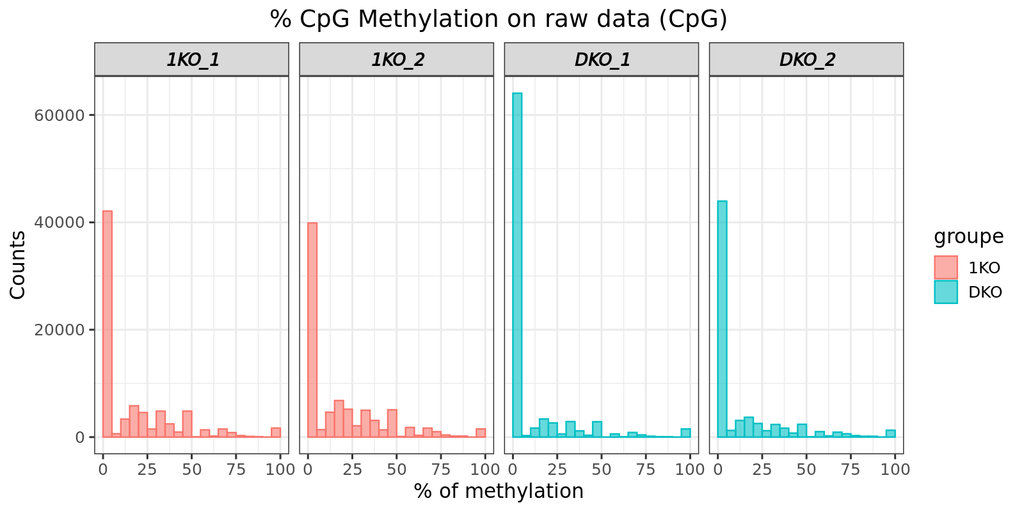

```r
#################################################################
# Methylation & coverage Statistics on raw data (cpg or tiles)

dfpc_dm <- NULL
groupe <- NULL

for(i in 1:length(dm_condi)){
    print(paste0(LEVEL, " raw data"))
    print("sample ID")
    print(dm_condi[[i]]@sample.id)

    groupe <- c(groupe, rep(strsplit(dm_condi[[i]]@sample.id, "_")[[1]][1], dim(dm_condi[[i]])[1]) )

    dm_condi[[i]] %>% getData() %>%
    dplyr::mutate(., Meth_perc = 100 * (numCs/coverage))  %>%
    dplyr::mutate(., ID = dm_condi[[i]]@sample.id) -> df_dm
    dfpc_dm <- rbind(dfpc_dm, df_dm)

    rm(df_dm)
}

dfpc_dm <- cbind(dfpc_dm, groupe)

#Plot of CpG Methylation on raw data (before filtering coverage and unite)
p_dm <- ggplot(dfpc_dm, aes(x=Meth_perc, fill=groupe, color=groupe)) +
  geom_histogram(position="identity",
                 alpha=0.6,
                 breaks = seq(0, 100, 5)) +
  ggtitle(paste0("% CpG Methylation on raw data ", "(", LEVEL, ")")) +
  facet_grid(. ~ ID ) +
  labs(x = "% of methylation",  y = "Counts") +
  theme_bw(base_size = 14) +
  theme(
    legend.title = element_text(),
    axis.title.x=element_text(),
    plot.title = element_text(hjust = 0.5),
    plot.subtitle = element_text(hjust = 0.5),
    strip.text.x = element_text(size = 12, color = "black", face = "bold.italic"))

p_dm
```

```r
rm(groupe)
```

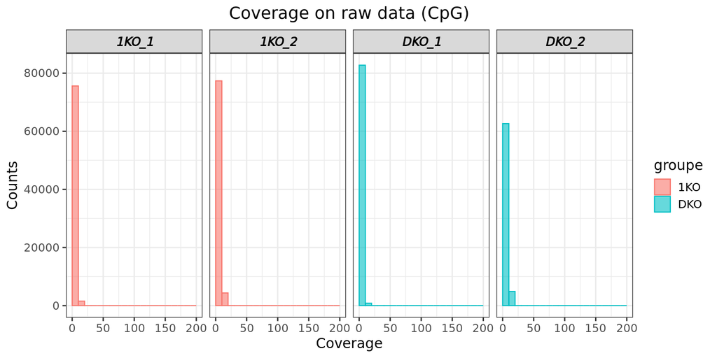

```r
cov_dm <- ggplot(dfpc_dm, aes(x=coverage, fill=groupe, color=groupe)) +
  geom_histogram(position="identity",
                 alpha=0.6,
                 breaks = seq(0, 200, 10)) +
  ggtitle(paste0("Coverage on raw data ", "(", LEVEL, ")")) +
  facet_grid(. ~ ID ) +
  labs(x = "Coverage",  y = "Counts") +
  theme_bw(base_size = 14) +
  theme(
    legend.title = element_text(),
    axis.title.x=element_text(),
    plot.title = element_text(hjust = 0.5),
    plot.subtitle = element_text(hjust = 0.5),
    strip.text.x = element_text(size = 12, color = "black", face = "bold.italic"))

cov_dm
```

```r
rm(dfpc_dm)
```

# 6 Methylation and coverage statistics on filtered data

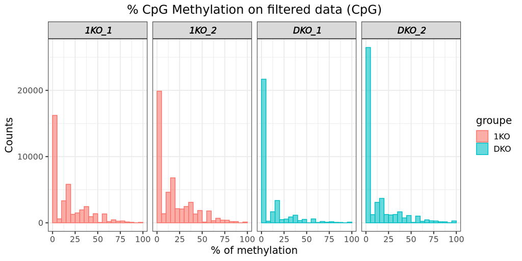

```r
#################################################################
# Methylation & coverage Statistics on filtered data

dfpc_fdm <- NULL
groupe <- NULL

for(i in 1:length(f.dm_condi)){
    print("f.dm_condi, filtered data")
    print("sample ID")
    print(f.dm_condi[[i]]@sample.id)

    groupe <- c(groupe, rep(strsplit(f.dm_condi[[i]]@sample.id, "_")[[1]][1], dim(f.dm_condi[[i]])[1]) )

    f.dm_condi[[i]] %>% getData() %>%
    dplyr::mutate(., Meth_perc = 100 * (numCs/coverage))  %>%
    dplyr::mutate(., ID = f.dm_condi[[i]]@sample.id) -> df_fdm
    dfpc_fdm <- rbind(dfpc_fdm, df_fdm)
    rm(df_fdm)
}

dfpc_fdm <- cbind(dfpc_fdm, groupe)

#Plot of CpG Methylation on filtered data
p_fdm <- ggplot(dfpc_fdm, aes(x=Meth_perc, fill=groupe, color=groupe)) +
  geom_histogram(position="identity",
                 alpha=0.6,
                 breaks = seq(0, 100, 5)) +
  ggtitle(paste0("% CpG Methylation on filtered data ", "(", LEVEL, ")")) +
  facet_grid(. ~ ID ) +
  labs(x = "% of methylation",  y = "Counts") +
  theme_bw(base_size = 14) +
  theme(
    legend.title = element_text(),
    axis.title.x=element_text(),
    plot.title = element_text(hjust = 0.5),
    plot.subtitle = element_text(hjust = 0.5),
    strip.text.x = element_text(size = 12, color = "black", face = "bold.italic"))

p_fdm
```

```r
rm(groupe)
```

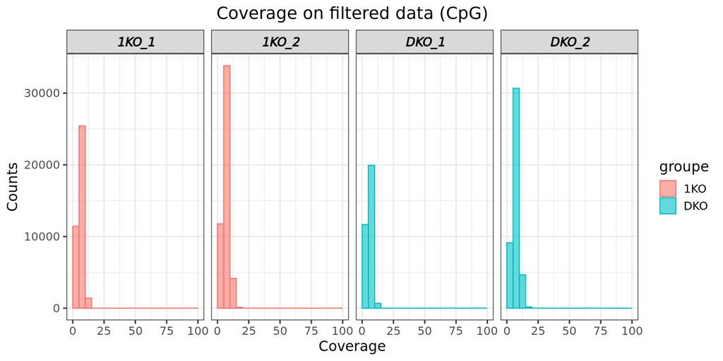

```r
cov_fdm <- ggplot(dfpc_fdm, aes(x=coverage, fill=groupe, color=groupe)) +
  geom_histogram(position="identity",
                 alpha=0.6,
                 breaks = seq(0, 100, 5)) +
  ggtitle(paste0("Coverage on filtered data ", "(", LEVEL, ")")) +
  facet_grid(. ~ ID) +
  labs(x = "Coverage",  y = "Counts") +
  theme_bw(base_size = 14) +
  theme(
    legend.title = element_text(),
    axis.title.x=element_text(),
    plot.title = element_text(hjust = 0.5),
    plot.subtitle = element_text(hjust = 0.5),
    strip.text.x = element_text(size = 12, color = "black", face = "bold.italic"))

cov_fdm
```

```r
rm(dfpc_fdm)
```

# 7 Barplot Methylation Status

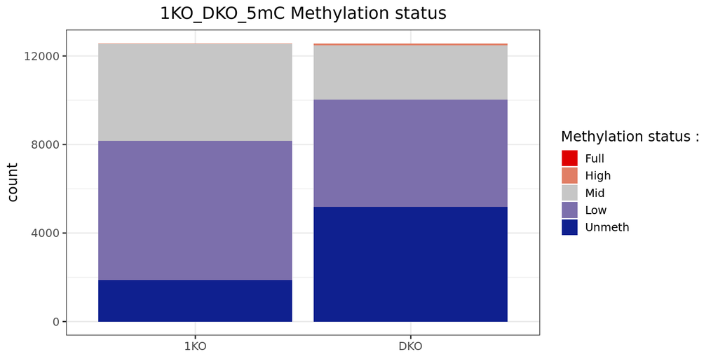

```r
#################################################################
#Barplot Methylation Status bpst object
#requires methst object

bpst <- ggplot(data=methst ,
               aes( x = condi, fill = factor( Methstatus, rev( levels(Methstatus) ) ) )
) +
  geom_bar() +
  labs(fill = '') +
  scale_fill_manual("Methylation status : ",
  values = c( 'Full' = full.color,
               'High' = high.color,
               'Mid'  = mid.color,
               'Low'  = low.color,
               'Unmeth' = unmeth.color)) +
  ggtitle(paste0(CONDI, " Methylation status") ) +
  theme_bw(base_size = 14)  +
  theme(axis.title.x=element_blank(),
        plot.title = element_text(hjust = 0.5))

bpst
```

# 8 Piechart of differentially methylated regions

These plots give the proportion of differentially methylated tiles or CpG present in the three categories:  
- Hyper: DKO > 1KO by more than 20 % and qvalue < 0.05  
- Hypo: DKO < 1KO by more than 20 % and qvalue < 0.05  
- None: no significant difference, qvalue > 0.05

The significance threshold of the methylation difference (20 %) is modifiable in the configuration file  
as well as the threshold on the qvalue (0.05).

```r
#################################################################
# Piechart Differentially methylated CpG or Tiles distribution
# piedm object on AllDiffdm$DM_status %>% table %>% data.frame

summary(AllDiffdm$DM_status)
```

```
## Hyper  Hypo  None
##   265  1285 11013
```

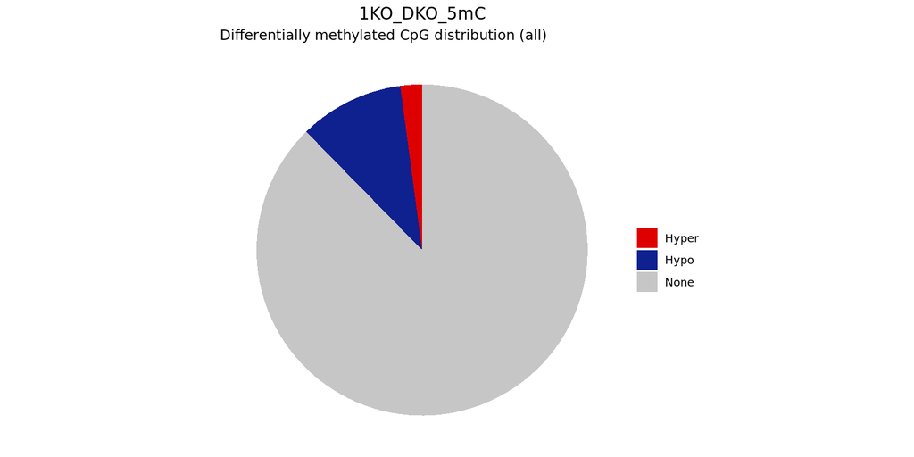

```r
piedm <- ggplot(AllDiffdm$DM_status %>% table %>% data.frame,
                aes(x="", y=Freq, fill=.)) +
  geom_col() +
  scale_fill_manual("", values = c( 'Hyper' = hyper.color,
                                    'Hypo'  = hypo.color,
                                    'None'  = not.color)
  ) +
  coord_polar("y", start=0) +
  theme_void() +
  ggtitle(paste0(CONDI),
          subtitle = paste0(" Differentially methylated ", LEVEL, " distribution (all)")
  ) +
  theme(plot.title = element_text(hjust = 0.5))

piedm
```

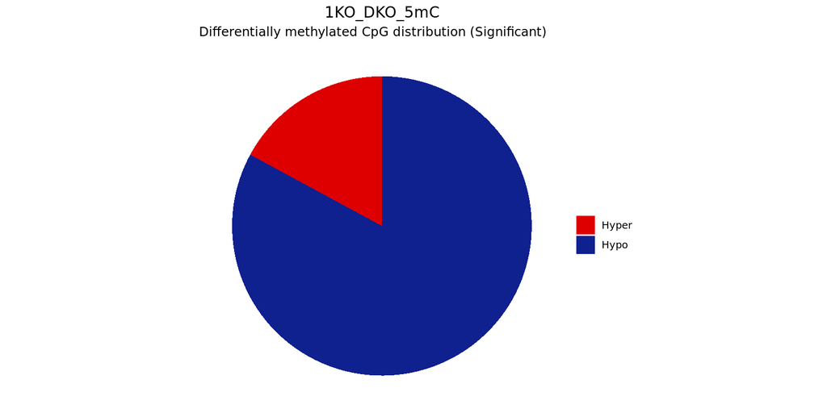

```r
# piedms object on  filter(AllDiffdm, DM_status != \"None\")  -> cnt
dplyr::filter(AllDiffdm, DM_status != "None") %>% dplyr::select(. , DM_status) %>% table %>% data.frame() -> cnt


piedms <- ggplot( cnt[-3,], aes(x="", y=Freq, fill=.) ) +
  geom_col() +
  scale_fill_manual("", values = c( 'Hyper' = hyper.color,
                                    'Hypo'  = hypo.color)
  ) +
  coord_polar("y", start=0) +
  theme_void() +
  ggtitle(paste0(CONDI),
          subtitle = paste0(" Differentially methylated " ,LEVEL,  " distribution (Significant)")
  ) +
  theme(plot.title = element_text(hjust = 0.5))

piedms
```

# 9 Barplots of differentially methylated regions as a fonction of initial methylation status, for all annotations

For each annotation track (promoters, exons …), the plots show the number of differentially methylated CpGs or tiles as a function of the methylation status in both conditions.

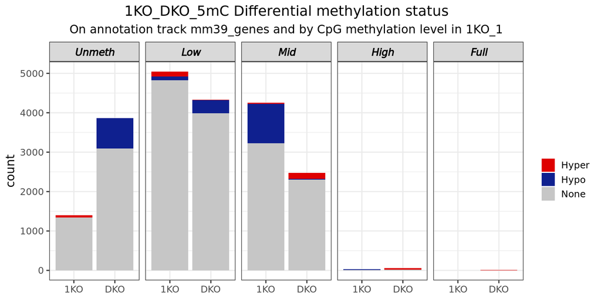

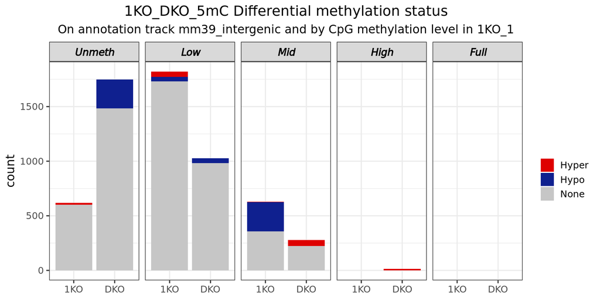

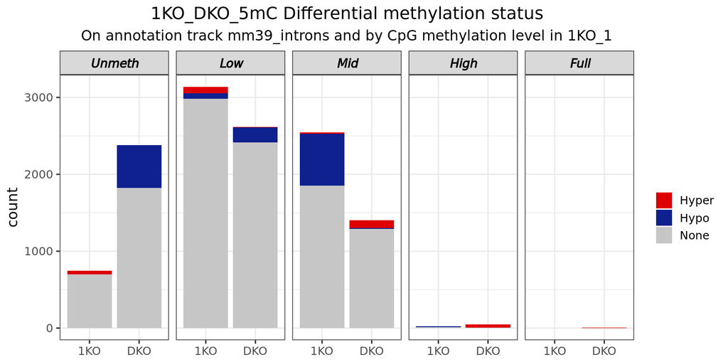

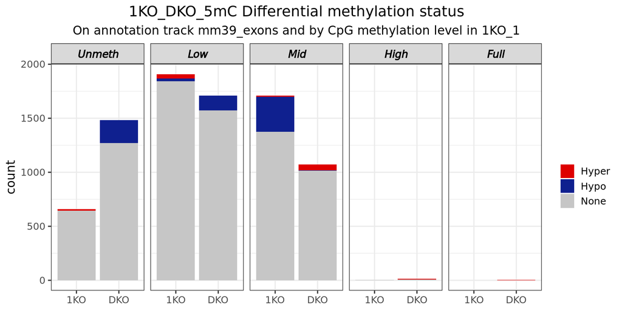

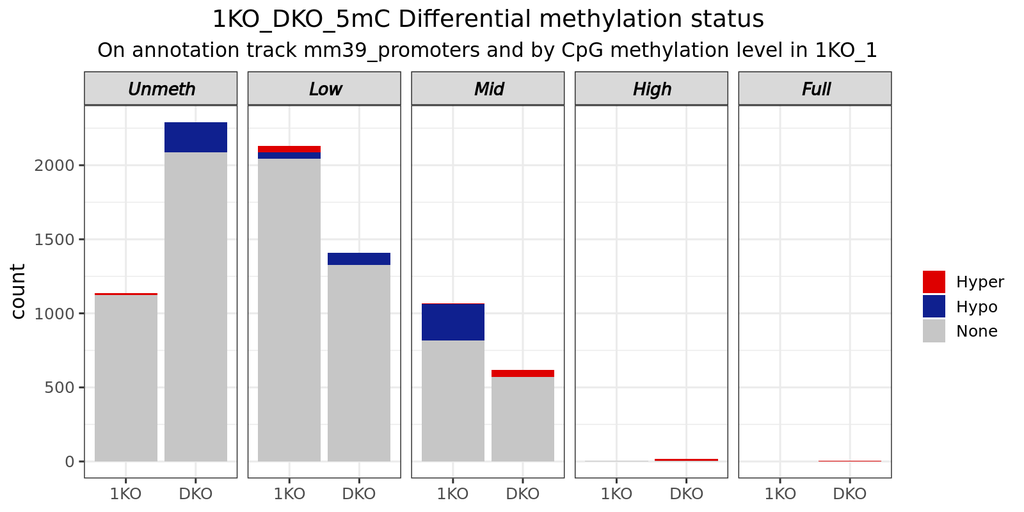

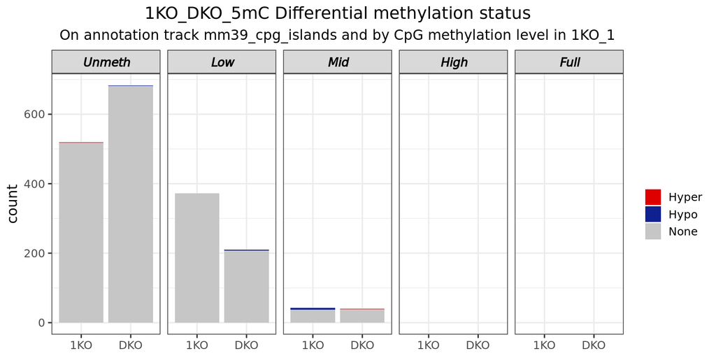

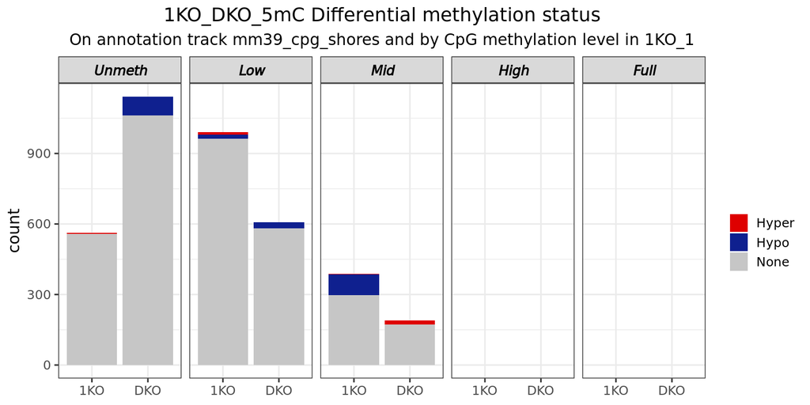

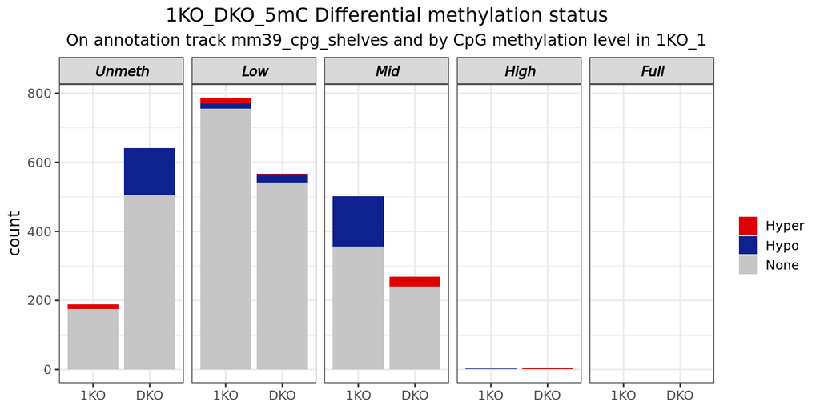

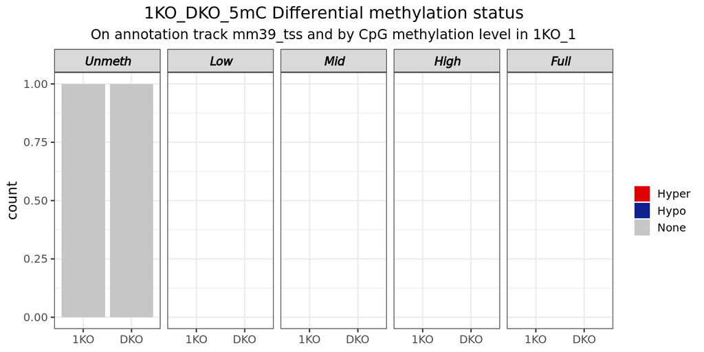

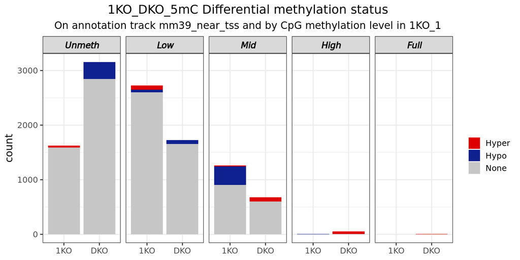

```r
#################################################################
# New barplot fraction low mid high in Diff meth on All the Annots


for(i in IGV ){

  dfpc_temp <- dfpc_annotated %>% data.frame
  dfpc_temp <-  dfpc_temp[ which( dfpc_temp$annot.type %in% i ) , ]

  exist_annot <- row.names(table(dfpc_temp$annot.type))
  if(is.na(match(x = i , exist_annot)) == FALSE){

    dfpc_temp$annot.type <- factor(dfpc_temp$annot.type, levels = IGV[i] )

    bp2ct <-  ggplot( dfpc_temp, aes(x=condi, fill = DM_status)) +
      geom_bar( ) +
      facet_grid(~Methstatus, drop = FALSE) +
      theme_bw(base_size = 14) +
      scale_fill_manual("", values = c( 'Hyper' = hyper.color,
                                        'Hypo'  = hypo.color,
                                        'None'  = not.color)
                        ) +
      ggtitle(paste0(label = CONDI, " Differential methylation status"),
              subtitle = paste0( "On annotation track ", i,
                                 " and by ", LEVEL, " methylation level in ",
                                 sample.ids[1])
      ) +
      theme(
        axis.title.x=element_blank(),
        plot.title = element_text(hjust = 0.5),
        plot.subtitle = element_text(hjust = 0.5),
        strip.text.x = element_text(size = 12, color = "black", face = "bold.italic")
      )
   print(bp2ct)
  }
}
```

```r
rm(dfpc_temp)
```

# 10 Histogram of methylation level (for all sites or significant only)

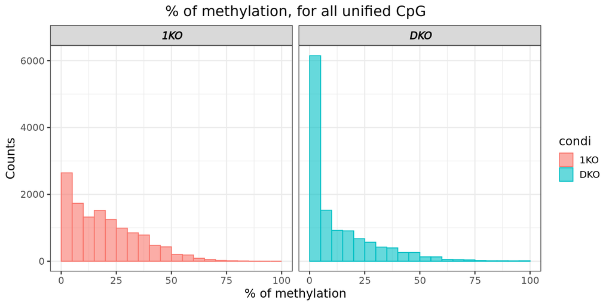

```r
#################################################################
#Histogram of methylation all
histmeth <- ggplot(dfpc %>% data.frame,
                   aes(x=Meth_perc*100, fill= condi, color= condi)
) +
  geom_histogram(position="identity",
                 alpha=0.6,
                 breaks = seq(0, 100, 5)) +
  ggtitle(paste0("% of methylation, for all unified ", LEVEL)) +
  facet_grid(. ~ condi, scales = "free", space = "free" ) +
  labs(x = "% of methylation",  y = "Counts") +
  theme_bw(base_size = 14) +
  theme(
    legend.title = element_text(),
    axis.title.x=element_text(),
    plot.title = element_text(hjust = 0.5),
    plot.subtitle = element_text(hjust = 0.5),
    strip.text.x = element_text(size = 12, color = "black", face = "bold.italic"))

histmeth
```

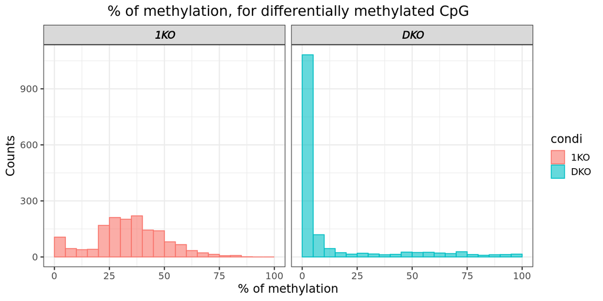

```r
#################################################################
#Histogram of methylation Signif
histmeths <-  ggplot(dfpc_Sig %>% data.frame,
                     aes(x=Meth_perc*100, fill= condi, color= condi)
) +
  geom_histogram(position="identity",
                 alpha=0.6,
                 breaks = seq(0, 100, 5)) +
  ggtitle(paste0("% of methylation, for differentially methylated ", LEVEL)) +
  facet_grid(. ~ condi, scales = "free", space = "free" ) +
  labs(x = "% of methylation",  y = "Counts") +
  theme_bw(base_size = 14) +
  theme(
    legend.title = element_text(),
    axis.title.x=element_text(),
    plot.title = element_text(hjust = 0.5),
    plot.subtitle = element_text(hjust = 0.5),
    strip.text.x = element_text(size = 12, color = "black", face = "bold.italic"))
histmeths
```

# 11 Histogram of methylation level (for all sites or significant only) by group

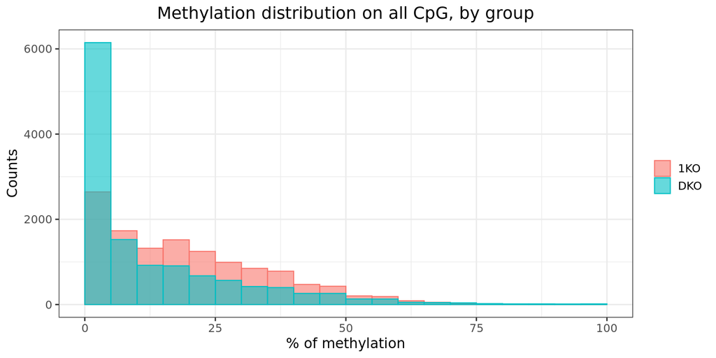

```r
#################################################################
#Histogram of methylation all by group

histmethg <- ggplot(dfpc %>% data.frame,
                   aes(x=Meth_perc*100, fill= condi, color= condi)
) +
  geom_histogram(position="identity",
                 alpha=0.6,
                 breaks = seq(0, 100, 5)) +
  ggtitle(paste0("Methylation distribution on all ", LEVEL, ", by group") ) +
  xlab("% of methylation") + ylab("Counts") +
  theme_bw(base_size = 14) +
  theme(legend.title = element_blank(),
        plot.title = element_text(hjust = 0.5))

histmethg
```

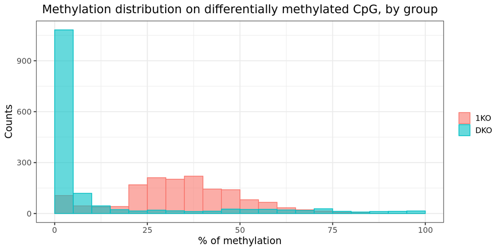

```r
#################################################################
#Histogram of methylation Signif by group
histmethsg <-  ggplot(dfpc_Sig %>% data.frame,
                     aes(x=Meth_perc*100, fill= condi, color=condi)
) +
  #scale_fill_manual(values=c("darkorange2", "cornflowerblue", "red", "yellow")) +
  geom_histogram(position="identity",
                 alpha=0.6,
                 breaks = seq(0, 100, 5)) +
  ggtitle(paste0("Methylation distribution on differentially methylated ", LEVEL, ", by group") ) +
  xlab("% of methylation") + ylab("Counts") +
  theme_bw(base_size = 14) +
  theme(legend.title = element_blank(),
        plot.title = element_text(hjust = 0.5))

histmethsg
```

# 12 Violin plot of methylation

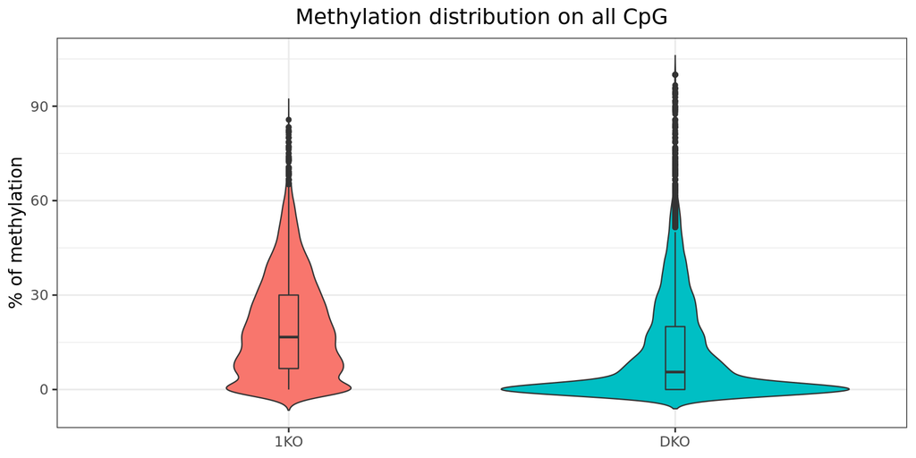

```r
#################################################################
#Violin plot of methylation All
#vp2
vp2 <- ggplot(dfpc, aes(x= condi, y=Meth_perc*100, fill = condi)) +
  geom_violin(trim=FALSE) +
  geom_boxplot(width=0.05) +
  labs(title = paste0("Methylation distribution on all ", LEVEL) ,
       x = "Samples", y = "% of methylation" )  +
  theme_bw(base_size = 14) +
  theme(axis.title.x=element_blank(),
        plot.title = element_text(hjust = 0.5),
        legend.position = "none")

vp2
```

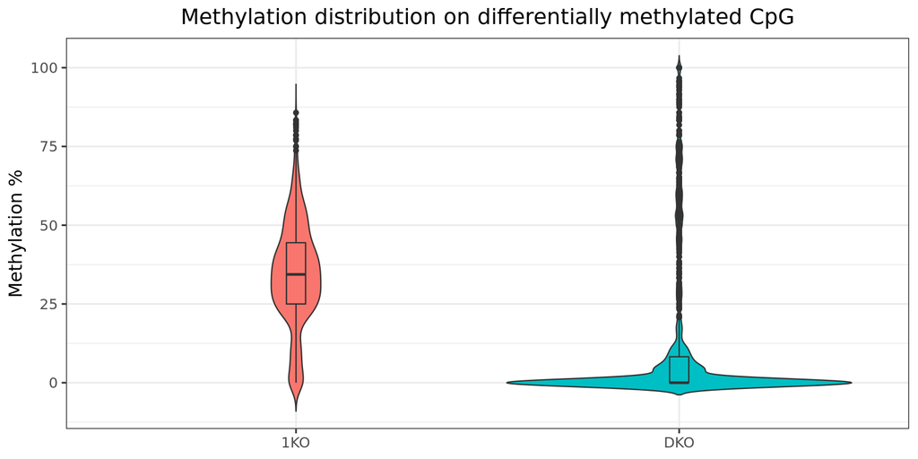

```r
#Violin plot of methylation Signif
#vp2s
vps2 <- ggplot(dfpc_Sig, aes(x= condi , y=Meth_perc*100, fill = condi)) +
  geom_violin(trim=FALSE) +
  geom_boxplot(width=0.05) +
  labs( title = paste0("Methylation distribution on differentially methylated ", LEVEL) ,
        x = "Samples", y = "Methylation %" )  +
  theme_bw(base_size = 14) +
  theme(axis.title.x=element_blank(),
        plot.title = element_text(hjust = 0.5),
        legend.position = "none")

vps2
```

# 13 Volcano plot

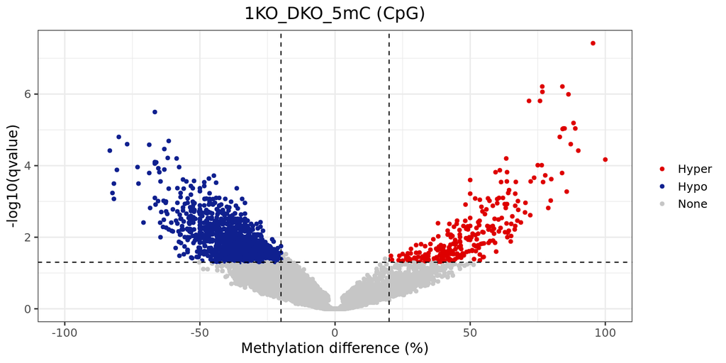

```r
#################################################################
#Volcano plot

if(min(AllDiffdm$qvalue) == 0){
  ymax <- .Machine$double.xmin  # if qvalue == 0 , set the ylim max at the smallest representable number in R (2.225074e-308)
}else{
  ymax <- min(AllDiffdm$qvalue)
}

vc <- ggplot(data = AllDiffdm,
             aes(x = meth.diff, y = -log10(qvalue), col = DM_status)) +
  geom_point() +
  theme_bw(base_size = 14) +
  labs(col = '') +
  xlab("Methylation difference (%)") +
  xlim(-100, 100) +
  ylim(0, -log10(ymax)) +
  scale_color_manual(values=c('Hyper' = hyper.color,
                              'Hypo' = hypo.color,
                              'None' = not.color)) +
  geom_vline(xintercept = c(-DIF, DIF), linetype="dashed", col="black") +
  geom_hline(yintercept = -log10(QV), linetype="dashed", col="black") +
  ggtitle(paste0(CONDI, " (", LEVEL, ")")) +
  theme(plot.title = element_text(hjust = 0.5))

vc
```